# Coursera Reproducible Research: Course Project 2

## Severe weather events in the US and their impacts on health and economy

# Synopsis

In this report, we aim to analyze the impact of different weather events on public health and economy based on the storm database collected from the U.S. National Oceanic and Atmospheric Administration’s (NOAA) from 1950 - 2011. We will use the estimates of fatalities, injuries, property and crop damage to decide which types of event are most harmful to the population health and economy. From these data, we found that excessive heat and tornado are most harmful with respect to population,health, while flood, drought, and hurricane/typhoon have the greatest economic consequences.

## Data Processing

The raw data were available from a URL provided by the Coursera project instructions, and were downloaded using the download.file() function in R:

```r
library(knitr)
library(markdown)
library(rmarkdown)
```

```r
library(plyr)
library(stats)

download.file("https://d396qusza40orc.cloudfront.net/repdata%2Fdata%2FStormData.c
sv.bz2","storms.csv.bz2")
```

The data were then read into R using the read.csv() function:

```r
storms <- read.csv("storms.csv.bz2",stringsAsFactors=F)
dim(storms)
```

```
## [1] 902297     37
```

```r
names(storms)
```

```
##  [1] "STATE__"    "BGN_DATE"   "BGN_TIME"   "TIME_ZONE"  "COUNTY"
##  [6] "COUNTYNAME" "STATE"      "EVTYPE"     "BGN_RANGE"  "BGN_AZI"
## [11] "BGN_LOCATI" "END_DATE"   "END_TIME"   "COUNTY_END" "COUNTYENDN"
## [16] "END_RANGE"  "END_AZI"    "END_LOCATI" "LENGTH"     "WIDTH"
## [21] "F"          "MAG"        "FATALITIES" "INJURIES"   "PROPDMG"
## [26] "PROPDMGEXP" "CROPDMG"    "CROPDMGEXP" "WFO"        "STATEOFFIC"
## [31] "ZONENAMES"  "LATITUDE"   "LONGITUDE"  "LATITUDE_E" "LONGITUDE_"
## [36] "REMARKS"    "REFNUM"
```

```r
str(storms)
```

```
## 'data.frame':    902297 obs. of  37 variables:
##  $ STATE__   : num  1 1 1 1 1 1 1 1 1 1 ...
##  $ BGN_DATE  : chr  "4/18/1950 0:00:00" "4/18/1950 0:00:00" "2/20/1951 0:00:00" "6/8/1951 0:00:00" ...
##  $ BGN_TIME  : chr  "0130" "0145" "1600" "0900" ...
##  $ TIME_ZONE : chr  "CST" "CST" "CST" "CST" ...
##  $ COUNTY    : num  97 3 57 89 43 77 9 123 125 57 ...
##  $ COUNTYNAME: chr  "MOBILE" "BALDWIN" "FAYETTE" "MADISON" ...
##  $ STATE     : chr  "AL" "AL" "AL" "AL" ...
##  $ EVTYPE    : chr  "TORNADO" "TORNADO" "TORNADO" "TORNADO" ...
##  $ BGN_RANGE : num  0 0 0 0 0 0 0 0 0 0 ...
##  $ BGN_AZI   : chr  "" "" "" "" ...
##  $ BGN_LOCATI: chr  "" "" "" "" ...
##  $ END_DATE  : chr  "" "" "" "" ...
##  $ END_TIME  : chr  "" "" "" "" ...
##  $ COUNTY_END: num  0 0 0 0 0 0 0 0 0 0 ...
```

[output cut: 23 more lines]

## Wrangling the Data

Defining variables that will be used:

EVTYPE: Event Type (Tornados, Flood, ..)

FATALITIES: Number of Fatalities

INJURIES: Number of Injuries

PROGDMG: Property Damage

PROPDMGEXP: Units for Property Damage (magnitudes - K,B,M)

CROPDMG: Crop Damage

CROPDMGEXP: Units for Crop Damage (magnitudes - K,BM,B)

```r
varsNeeded <- c("EVTYPE", "FATALITIES", "INJURIES", "PROPDMG", "PROPDMGEXP",
"CROPDMG", "CROPDMGEXP")
storms <- storms[varsNeeded]
dim(storms)
```

```
## [1] 902297      7
```

```r
names(storms)
```

```
## [1] "EVTYPE"     "FATALITIES" "INJURIES"   "PROPDMG"    "PROPDMGEXP"
## [6] "CROPDMG"    "CROPDMGEXP"
```

## Total for Property Damage

Refactor of variable PROPDNGEXP

```r
unique(storms$PROPDMGEXP)
```

```
##  [1] "K" "M" ""  "B" "m" "+" "0" "5" "6" "?" "4" "2" "3" "h" "7" "H" "-"
## [18] "1" "8"
```

```r
storms$PROPDMGEXP <- mapvalues(storms$PROPDMGEXP, from = c("K", "M","", "B", "m",
"+", "0", "5", "6", "?", "4", "2", "3", "h", "7", "H", "-", "1", "8"), to =
c(10^3, 10^6, 1, 10^9, 10^6, 0,1,10^5, 10^6, 0, 10^4, 10^2, 10^3, 10^2, 10^7,
10^2, 0, 10, 10^8))
storms$PROPDMGEXP <- as.numeric(as.character(storms$PROPDMGEXP))
storms$PROPDMGTOTAL <- (storms$PROPDMG * storms$PROPDMGEXP)/1000000000
```

Refactor of variable CROPDMGEXP variable

```r
unique(storms$CROPDMGEXP)
```

```
## [1] ""  "M" "K" "m" "B" "?" "0" "k" "2"
```

```r
storms$CROPDMGEXP <- mapvalues(storms$CROPDMGEXP, from = c("","M", "K", "m", "B",
"?", "0", "k","2"), to = c(1,10^6, 10^3, 10^6, 10^9, 0, 1, 10^3, 10^2))
storms$CROPDMGEXP <- as.numeric(as.character(storms$CROPDMGEXP))
storms$CROPDMGTOTAL <- (storms$CROPDMG * storms$CROPDMGEXP)/1000000000
```

# Events that are Most Harmful to Population Health

To determine which type of events are most harmful to the population health we must look at the variables fatalities and Injuries.

# 1. Fatalities

```r
sumFatalities <- aggregate(FATALITIES ~ EVTYPE, data = storms,  FUN="sum")
dim(sumFatalities)
```

```
## [1] 985   2
```

Ordering Number of Fatalities and defining the top 10 Weather events

```r
fatalities10events <- sumFatalities[order(-sumFatalities$FATALITIES), ][1:10, ]
dim(fatalities10events)
```

```
## [1] 10  2
```

```r
fatalities10events
```

```
##             EVTYPE FATALITIES
## 834        TORNADO       5633
## 130 EXCESSIVE HEAT       1903
## 153    FLASH FLOOD        978
## 275           HEAT        937
## 464      LIGHTNING        816
## 856      TSTM WIND        504
## 170          FLOOD        470
## 585    RIP CURRENT        368
## 359      HIGH WIND        248
## 19       AVALANCHE        224
```

BarPlot of the 10 Fatalities Events most harmful to population Health.

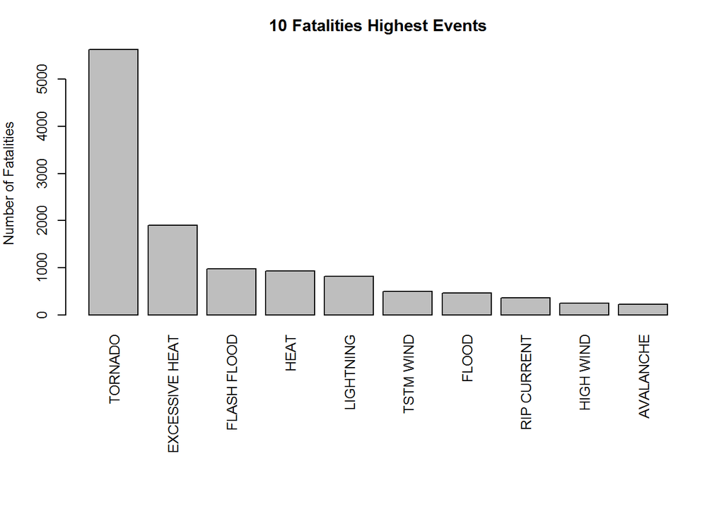

```r
par(mfrow = c(1,1), mar = c(12, 4, 3, 2), mgp = c(3, 1, 0), cex = 0.8)
barplot(fatalities10events$FATALITIES, names.arg = fatalities10events$EVTYPE, las
= 3, main = "10 Fatalities Highest Events", ylab = "Number of Fatalities")
```

```r
dev.copy(png, "fatalities-events.png", width = 480, height = 480)
```

```r
dev.off()
```

# 2. Injuries

Number of Injuries per type of Event (EVTYPE)

```r
sumInjuries <- aggregate(INJURIES ~ EVTYPE, data = storms,  FUN="sum")
dim(sumInjuries)
```

```
## [1] 985   2
```

Ordering Number of INJURIES and defining the top 10 Weather events in this category

```r
injuries10events <- sumInjuries[order(-sumInjuries$INJURIES), ][1:10, ]
dim(injuries10events)
```

```
## [1] 10  2
```

```r
injuries10events
```

```
##                EVTYPE INJURIES
## 834           TORNADO    91346
## 856         TSTM WIND     6957
## 170             FLOOD     6789
## 130    EXCESSIVE HEAT     6525
## 464         LIGHTNING     5230
## 275              HEAT     2100
## 427         ICE STORM     1975
## 153       FLASH FLOOD     1777
## 760 THUNDERSTORM WIND     1488
## 244              HAIL     1361
```

```r
dev.copy(png, "injuries-events.png", width = 480, height = 480)
```

```r
dev.off()
```

# Events that have the Greatest Economic Consequences

To determine which type of events have the greatest econimic consequences the variables, PROPDMG (Property Damage) and CROPDMG (Crop Damage) have to be taken into consideration.

# 1.Property Damage

Calculation of property Damage

```r
sumPropertyDamage <- aggregate(PROPDMGTOTAL ~ EVTYPE, data = storms,  FUN="sum")
dim(sumPropertyDamage)
```

```
## [1] 985   2
```

Top 10 highest Property damage Events

```r
propdmg10Total <- sumPropertyDamage[order(-sumPropertyDamage$PROPDMGTOTAL),
][1:10, ]
propdmg10Total
```

```
##                EVTYPE PROPDMGTOTAL
## 170             FLOOD   144.657710
## 411 HURRICANE/TYPHOON    69.305840
## 834           TORNADO    56.947381
## 670       STORM SURGE    43.323536
## 153       FLASH FLOOD    16.822674
## 244              HAIL    15.735268
## 402         HURRICANE    11.868319
## 848    TROPICAL STORM     7.703891
## 972      WINTER STORM     6.688497
## 359         HIGH WIND     5.270046
```

BarPlot of the top 10 events most harmful to population economic.

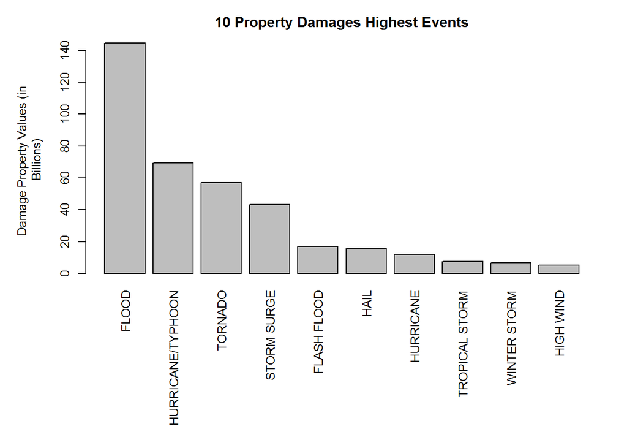

```r
par(mfrow = c(1,1), mar = c(12, 6, 3, 2), mgp = c(3, 1, 0), cex = 0.8)
barplot(propdmg10Total$PROPDMGTOTAL, names.arg = propdmg10Total$EVTYPE, las = 3,
main = "10 Property Damages Highest Events", ylab = "Damage Property Values (in
Billions)")
```

```r
dev.copy(png, "propdmg-total.png", width = 480, height = 480)
```

```r
dev.off()
```

# 2. Crop Damage

```r
sumCropDamage <- aggregate(CROPDMGTOTAL ~ EVTYPE, data = storms,  FUN="sum")
dim(sumCropDamage)
```

```
## [1] 985   2
```

Top 10 highest crop damage events

```r
cropdmg10Total <- sumCropDamage[order(-sumCropDamage$CROPDMGTOTAL), ][1:10, ]
cropdmg10Total
```

```
##                EVTYPE CROPDMGTOTAL
## 95            DROUGHT    13.972566
## 170             FLOOD     5.661968
## 590       RIVER FLOOD     5.029459
## 427         ICE STORM     5.022113
## 244              HAIL     3.025954
## 402         HURRICANE     2.741910
## 411 HURRICANE/TYPHOON     2.607873
## 153       FLASH FLOOD     1.421317
## 140      EXTREME COLD     1.292973
## 212      FROST/FREEZE     1.094086
```

BarPlot of the 10 Crop Damage Events most harmful to population economic.

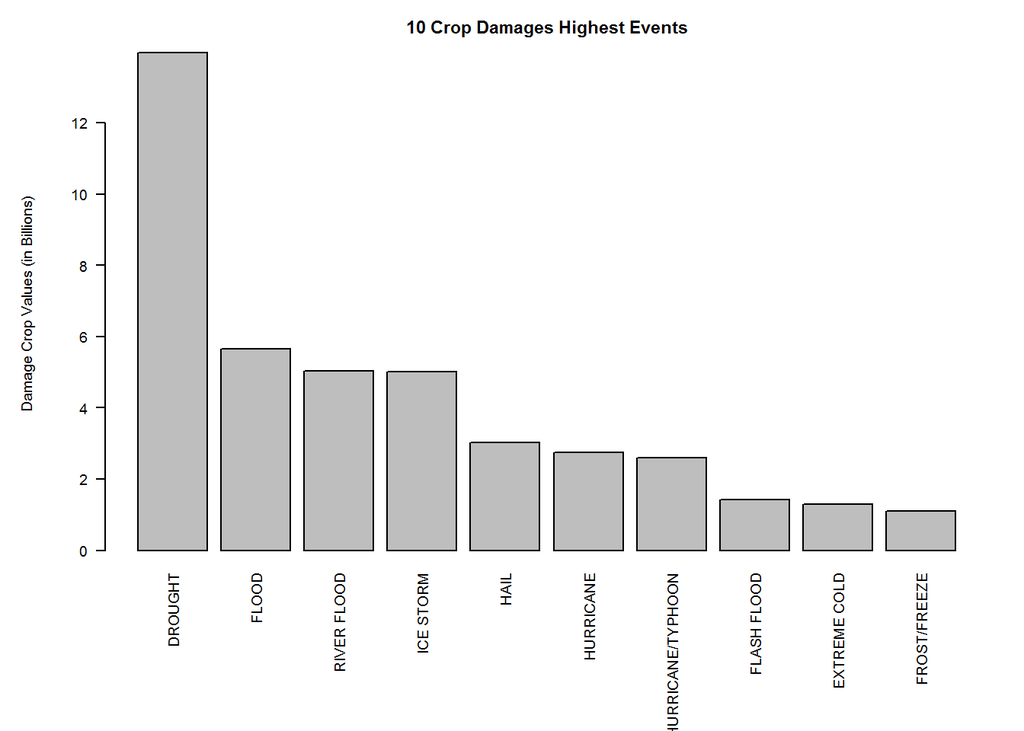

```r
par(mfrow = c(1,1), mar = c(10, 6, 3, 2), mgp = c(3, 1, 0), cex = 0.6)
barplot(cropdmg10Total$CROPDMGTOTAL, names.arg = cropdmg10Total$EVTYPE, las = 2,
main = "10 Crop Damages Highest Events", ylab = "Damage Crop Values (in Billions)
")
```

```r
dev.copy(png, "cropdmg-total.png", width = 480, height = 480)
```

```r
dev.off()
```

## Final Notes

It should be noted that the event rates computed here do not take account of two important factors: time and area. A HEATWAVE event usually takes place over several days and in a large area, as do cold weather events, tropical storms, hurricances, and others. Some events may be unlisted in the rankings because they take place over a shorter time period and/or act over a smaller area, putting fewer people and less property at risk. A more thorough analysis should take these factors into account, potentially by computing the rankings within a higher level of weather event category, over geographic size categories, and by duration. As always, asking the right question and understanding the data are paramount to reaching good conclusions.